# Down Sampling the Olympics Data

Aakash Pahuja

```r
# basic imports
library("fpp")
```

```r
library("ggplot2")
library("stats")
library("zoo")
library("TSA")
library("xts")
```

#### Importing the data

```r
rio <- data.matrix(read.csv("train_1.csv", header = TRUE, row.names = 1,sep = ",",nrows = 1,skip = 12186))
```

#### Preparing data to make it ready for time-series

```r
# removing column names
dimnames(rio) <- NULL
# converting to array
rio <- array(rio)
# checking the values
head(rio)
```

```
## [1] 4893 4620 4000 3874 4385 7519
```

```r
# no. of ovservations
length(rio)
```

```
## [1] 550
```

#### Looking at the entire data -

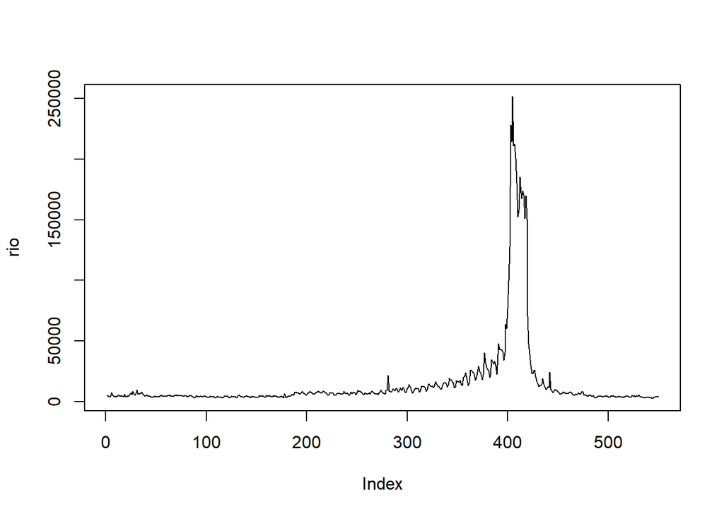

```r
plot(rio,type = 'l')
```

```r
# converting to time-series
time_index <- seq(from = as.POSIXct("2015-07-01"),to = as.POSIXct("2016-12-31"), by = "day")
rio_ts <- xts(rio, order.by =time_index ,frequency = 365.25)
# checking first few values
head(rio_ts)
```

```
##            [,1]
## 2015-07-01 4893
## 2015-07-02 4620
## 2015-07-03 4000
## 2015-07-04 3874
## 2015-07-05 4385
## 2015-07-06 7519
```

#### Lets convert our data from daily to weekly using rollapply by taking the mean of the last 7 values

```r
rio_week = rollapply(rio_ts[,1], 7, mean, by=7)
```

```r
head(rio_week, 14)
```

```
##                [,1]
## 2015-07-01       NA
## 2015-07-02       NA
## 2015-07-03       NA
## 2015-07-04       NA
## 2015-07-05       NA
## 2015-07-06       NA
## 2015-07-07 4944.143
## 2015-07-08       NA
## 2015-07-09       NA
## 2015-07-10       NA
## 2015-07-11       NA
## 2015-07-12       NA
## 2015-07-13       NA
## 2015-07-14 4308.714
```

#### Removing the NA values in our weekly dataset

```r
rio_week = na.remove(rio_week[,1])
```

```r
class(rio_week)
```

```
## [1] "matrix" "array"
```

#### Checking for the length of the data

```r
length(rio_week)
```

```
## [1] 78
```

#### Lets plot it

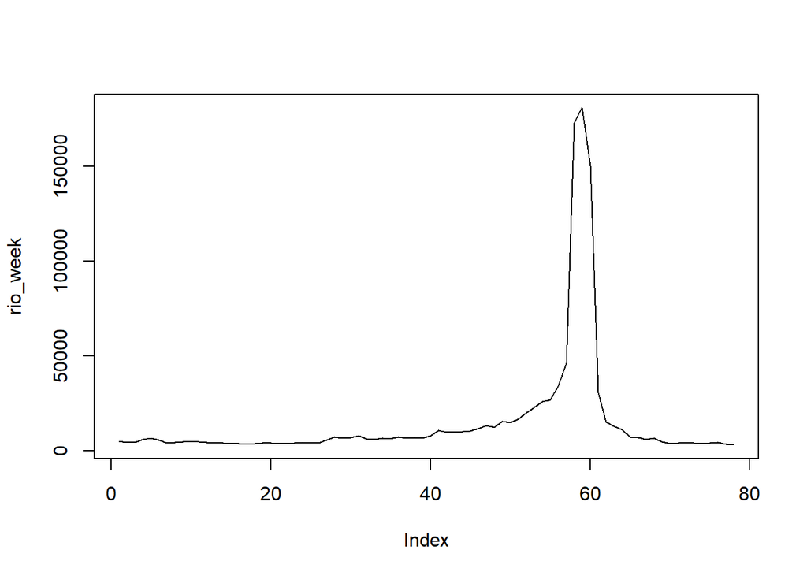

```r
plot(rio_week,type = 'l')
```

#### Lets convert the weekly data into time series

```r
rio_week_ts <- ts(rio_week,frequency = 1)
```

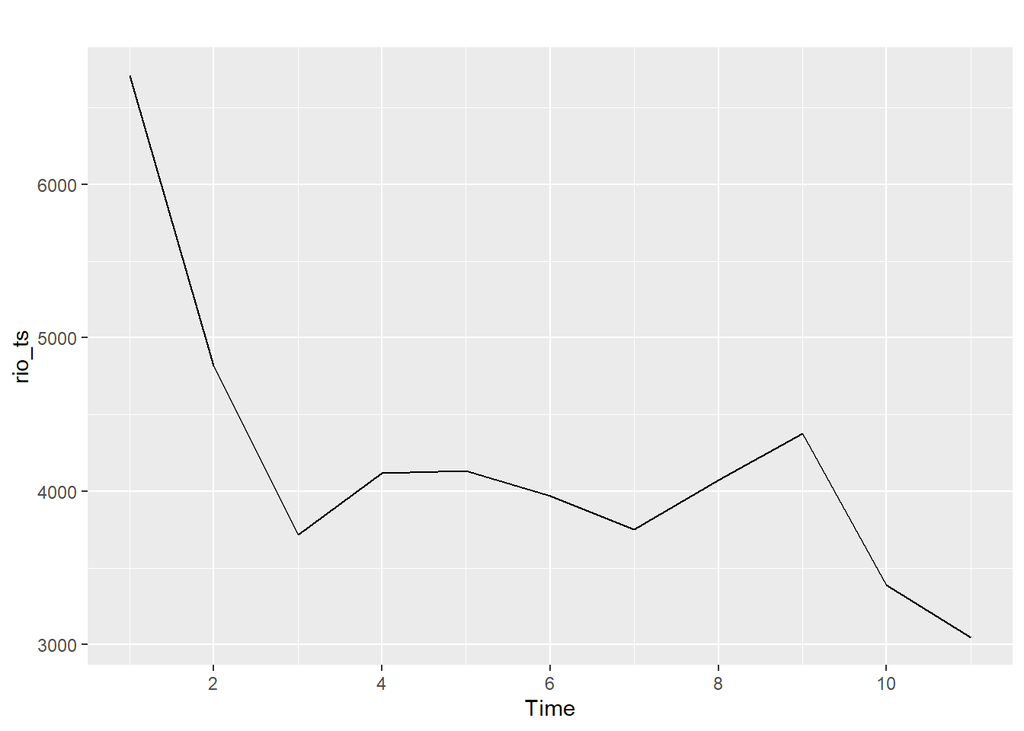

```r
rio1 <- rio_week[68:78]
# converting data to ts
rio_ts <- ts(rio1,frequency = 1)
# plotting the time-series
autoplot(rio_ts)
```

#### Train Test Split, we wil take the last month which is the month of December 2016 as our test

```r
rio_week_train <- rio_week_ts[1:74]
rio_week_test <- rio_week_ts[75:78]
# converting to time-series
rio_week_train <- ts(rio_week_train)
rio_week_test <- ts(rio_week_test)
```

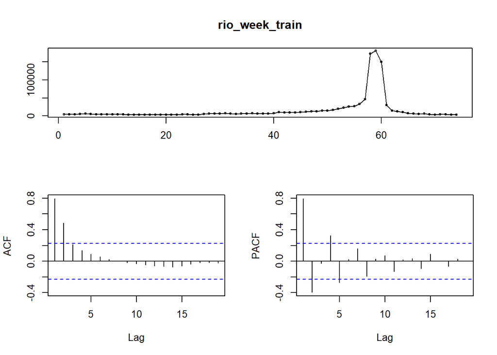

```r
tsdisplay(rio_week_train)
```

#### We will apply the Box Cox transformation just to transform the non-normal dependent variables into a normal shape. Lets check of our lambda value

```r
BoxCox.lambda(rio_week_train)
```

```
## [1] -0.6006535
```

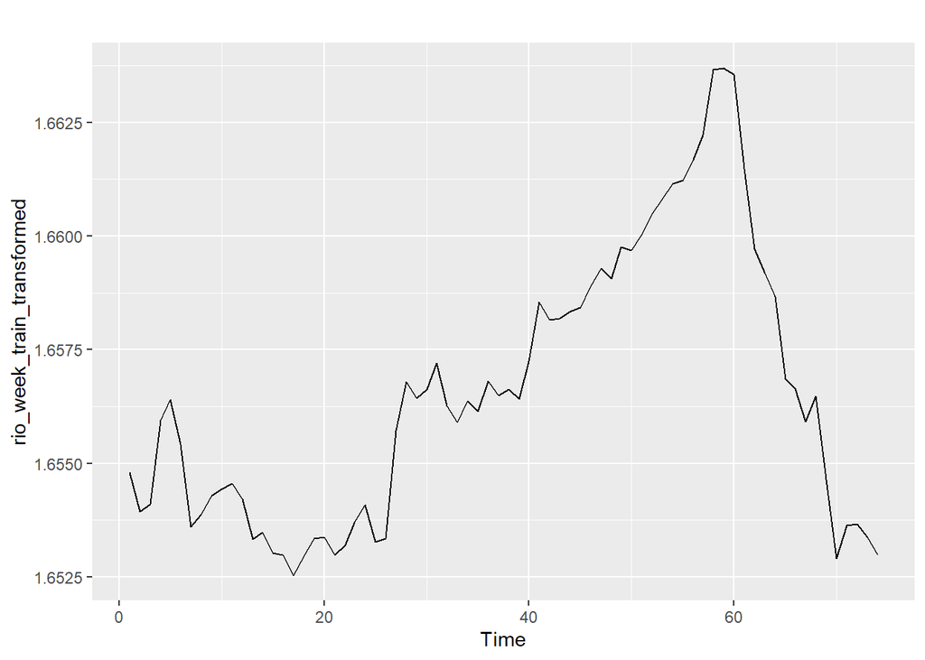

```r
rio_week_train_transformed <- BoxCox(rio_week_train,lambda = -0.6006535)
autoplot(rio_week_train_transformed)
```

#### Lets not stick with the transformation because There is very slow decay of the ACF which indicates this data is **NOT stationary**. And most of the lags are crossing the confidence boundary intervals, which show that they are not white noise.

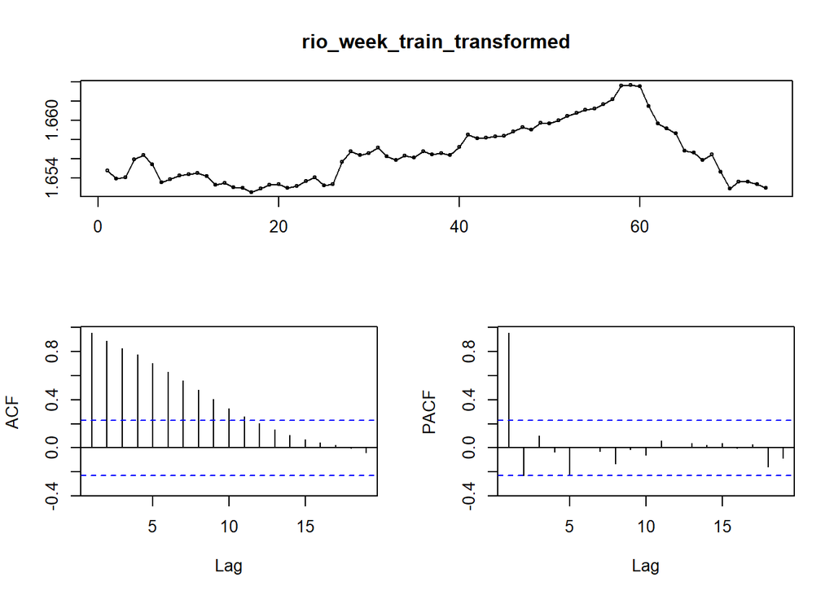

```r
tsdisplay(rio_week_train_transformed)
```

### Lets apply Differencing to help stabilise the mean of a time series

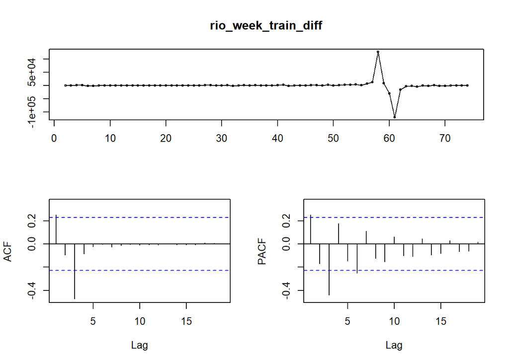

```r
# differencing
rio_week_train_diff <- diff(rio_week_train)
# visulalizing
tsdisplay(rio_week_train_diff)
```

```r
kpss.test(rio_week_train_diff)
```

```
##
##  KPSS Test for Level Stationarity
##
## data:  rio_week_train_diff
## KPSS Level = 0.035846, Truncation lag parameter = 3, p-value = 0.1
```

Here, p-value = 0.1  
=> The data **is stationary**

#### Lets apply the auto.arima

```r
auto.arima(rio_week_train, seasonal = TRUE ,lambda = 'auto')
```

```
## Series: rio_week_train
## ARIMA(0,1,1)
## Box Cox transformation: lambda= -0.6006535
##
## Coefficients:
##          ma1
##       0.3415
## s.e.  0.1103
##
## sigma^2 estimated as 6.268e-07:  log likelihood=420.46
## AIC=-836.92   AICc=-836.75   BIC=-832.34
```

#### Lets apply the ARIMA model with the same parameters given by the auto.arima function

```r
m2 <-Arima(rio_week_train,order=c(0,1,1), lambda = -0.6006535)
m2
```

```
## Series: rio_week_train
## ARIMA(0,1,1)
## Box Cox transformation: lambda= -0.6006535
##
## Coefficients:
##          ma1
##       0.3415
## s.e.  0.1103
##
## sigma^2 estimated as 6.268e-07:  log likelihood=420.46
## AIC=-836.92   AICc=-836.75   BIC=-832.34
```

#### Lets forecast for the next 4 values

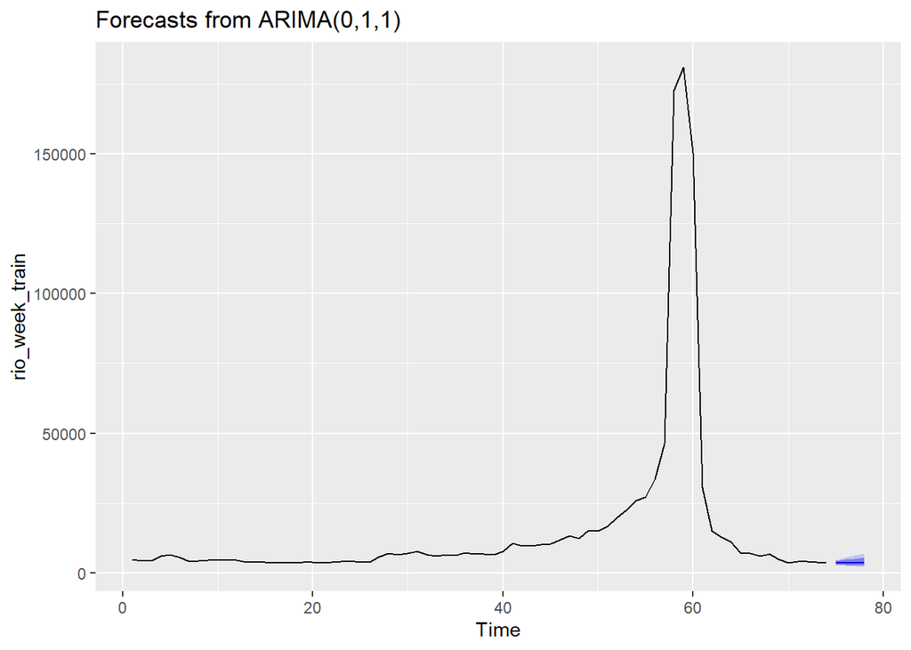

```r
autoplot(forecast(m2,h=4))
```

```r
predicted_arima = forecast(m2,h=4)
```

#### Lets check the residuals of our model

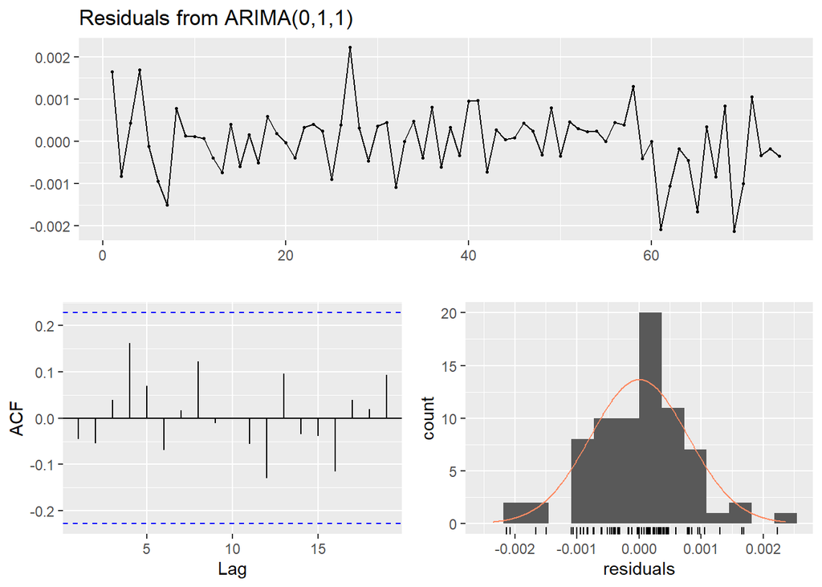

```
##
##  Ljung-Box test
##
## data:  Residuals from ARIMA(0,1,1)
## Q* = 4.7131, df = 9, p-value = 0.8586
##
## Model df: 1.   Total lags used: 10
```

```r
checkresiduals(m2)
```

From the time-series of the residuals, we see that its mean = 0 => our model is not biased.

From ACF plot, we see that the ACF of the residuals are almost white noise. There is no significant correlations between the residuals. This implies that our model performed well.From the histogram, we can see that the residuals are fairly normally distributed.Even the p-value for the Ljung Box Test is greater than 0.05.

```r
predicted_arima
```

```
##    Point Forecast    Lo 80    Hi 80    Lo 95    Hi 95
## 75       3689.375 3222.754 4274.383 3012.788 4646.720
## 76       3689.375 2959.513 4756.896 2662.239 5538.251
## 77       3689.375 2795.060 5148.978 2453.998 6338.304
## 78       3689.375 2671.315 5509.137 2302.573 7138.919
```

```r
as.array(rio_week_test)
```

```
## Time Series:
## Start = 1
## End = 4
## Frequency = 1
## [1] 4072.286 4375.286 3390.000 3049.000
```

#### Lets check the accuracy for the forecasted vs the test dataset

```r
accuracy(predicted_arima, rio_week[75:78])
```

```
##                       ME       RMSE       MAE       MPE     MAPE       MASE
## Training set -2365.08487 30228.8853 6999.0619 -6.228438 18.93548 1.35477705
## Test set        32.26741   528.3937  502.1429 -1.188544 13.72842 0.09719754
##                    ACF1
## Training set -0.3333713
## Test set             NA
```

We do notice **underfitting** in the model, this is because of the small dataset we have, and the purpose of the project was intervention analyses.

#### ETS

```r
rio_ets_fit <- ets(rio_week_train_diff,lambda = "auto")
```

#### Lets forecast for the next 4 values

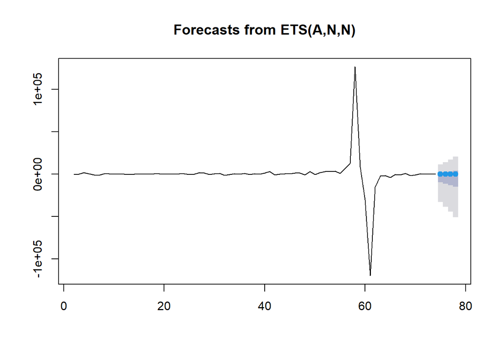

```r
plot(forecast(rio_ets_fit,h=4))
```

#### Lets check the residuals of our model

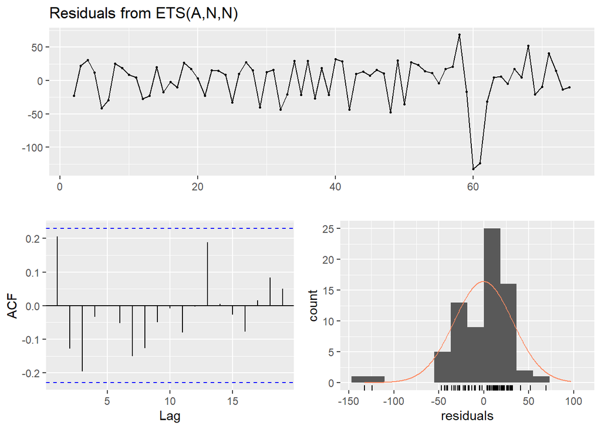

```
##
##  Ljung-Box test
##
## data:  Residuals from ETS(A,N,N)
## Q* = 11.215, df = 8, p-value = 0.1898
##
## Model df: 2.   Total lags used: 10
```

```r
checkresiduals(rio_ets_fit)
```

From the time-series of the residuals, we see that its mean = 0 => our model is not biased.

From ACF plot, we see that the ACF of the residuals are almost white noise. There is no significant correlations between the residuals. This implies that our model performed well.From the histogram, we can see that the residuals are fairly normally distributed.Even the p-value for the Ljung Box Test is greater than 0.05.

#### Lets check the accuracy for the forecasted vs the test dataset

```r
predicted_ets = forecast(rio_ets_fit,h=4)
```

```r
accuracy(predicted_ets, rio_week[75:78])
```

```
##                     ME      RMSE      MAE       MPE     MAPE      MASE
## Training set -490.1461 20932.967 5305.640  79.95043 114.8202 0.6874197
## Test set     3761.0839  3797.882 3761.084 101.08175 101.0817 0.4873009
##                   ACF1
## Training set 0.2357513
## Test set            NA
```

We have the same conlusion as the ARIMA model, but the difference is less for the error metrics between the Train and the Test set

#### ARFIMA

```r
rio_arfima = arfima(rio_week_train_diff)
```

#### Lets forecast for the next 4 values

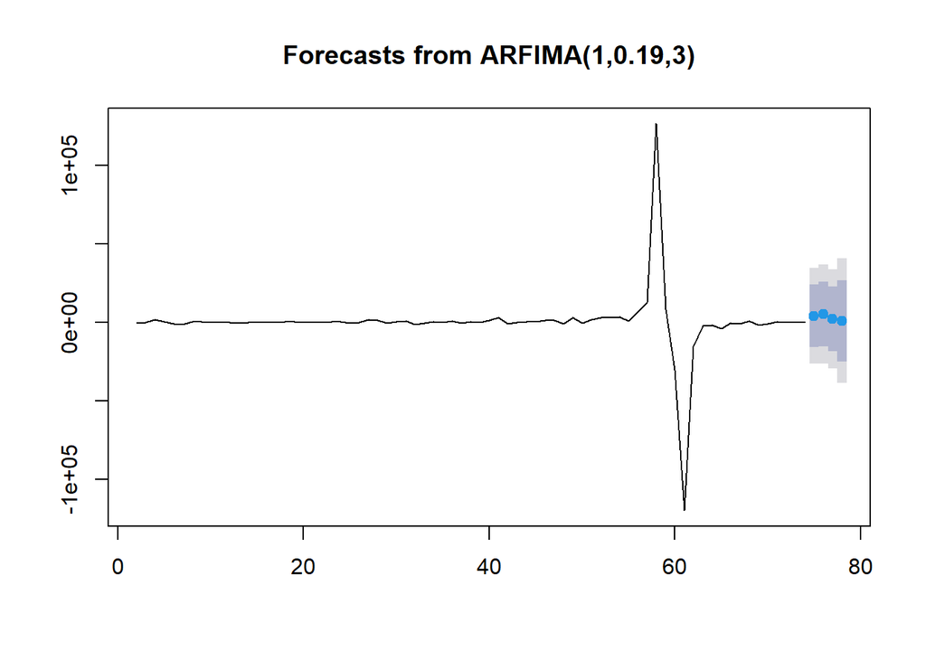

```r
plot(forecast(rio_arfima,h=4))
```

#### Lets check the residuals of our model

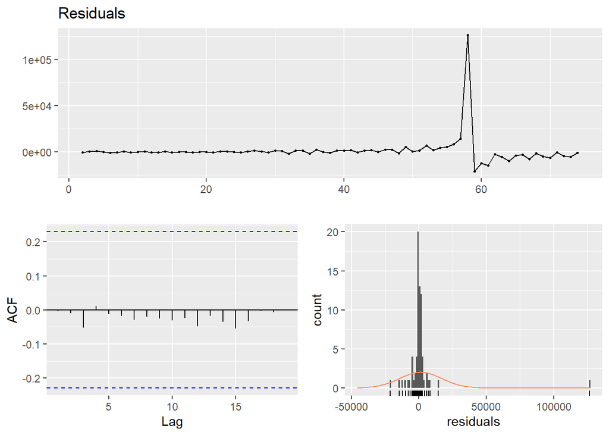

```r
checkresiduals(rio_arfima)
```

From the time-series of the residuals, we see that its mean = 0 => our model is not biased.

#### Lets check the accuracy for the forecasted vs the test dataset

```r
predicted_arfima = forecast(rio_arfima,h=4)
```

```r
accuracy(predicted_arfima, rio_week[75:78])
```

```
##                     ME      RMSE      MAE        MPE      MAPE      MASE
## Training set 1163.0238 15551.693 4364.965 -135.09250 644.95555 0.5655422
## Test set      652.5337  1346.839 1121.984   22.48034  33.20994 0.1453687
##                     ACF1
## Training set -0.00401955
## Test set              NA
```

Over here we have the same issue as the other two models applied